# Alcohol vs Seat choice

Shaun ikeuchi

Fall 2020

## Our Goal is to answer this question Is there a difference between the alcohol consumed between the row

## you choose to sit in??

Data are from the UCDavis.csv Is the average amount of alcohol consumer per week different for the different seating rows?

Null Hypothesis: There is no difference in the average amount of alcohol consumer per week based on seating row

Alternative Hypothesis: There is a difference in the average amount of alcohol consumed per week based on seating row

#Methods We predict alcohol consumption based on row.

alcohol ~ Seat Alcohol is a numeric variable Seat is a categorical variable. So we use the numerical categorical helper file. ## Now with ggplot - first select the basic data

```r
basicCN <- ggplot(davisdata,aes(y=alcohol,x=Seat))
```

## Now add in boxplot

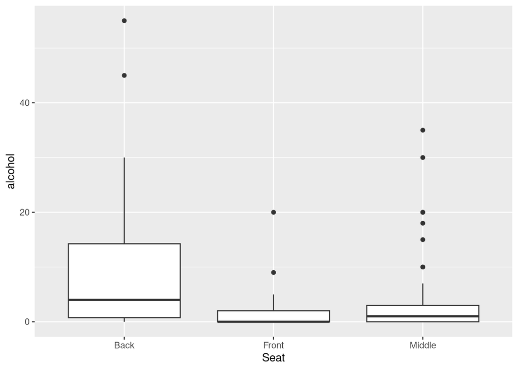

```r
basicCN + geom_boxplot()
```

### get fancy

```
## Notch went outside hinges
## ℹ Do you want `notch = FALSE`?
## Notch went outside hinges
## ℹ Do you want `notch = FALSE`?
```

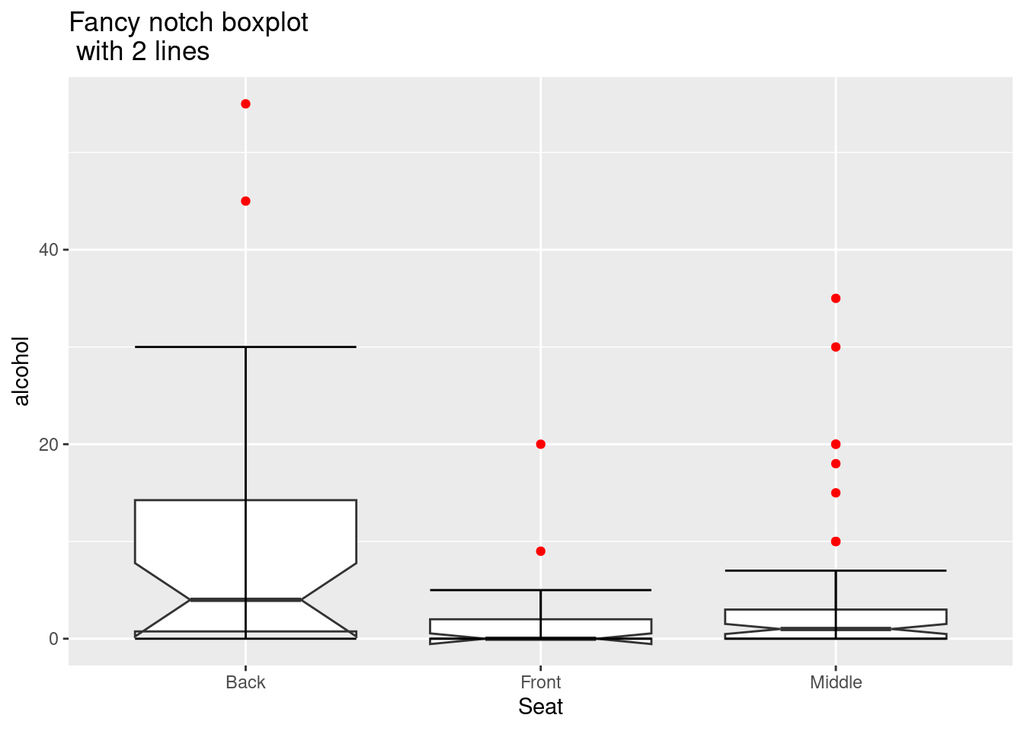

```r
basicCN + geom_boxplot(notch=TRUE,outlier.color = "red") + stat_boxplot(geom ='errorbar') + labs(title="Fancy notch boxplot \n with 2 lines")
```

The box plot shows that people sitting in the back row drank more alcohol compared to the front and middle rows.